# CS 439 - Introduction to Data Science

## Voting Classifier on Test Dataset

```python
prediction_vr_classifer_test = vr_classifer.predict(X_test)
```

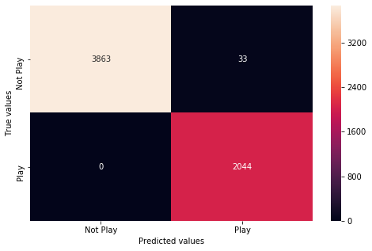

```python
plt.figure(figsize=(8,5))
c_matix = confusion_matrix_with_sns( y_test, prediction_vr_classifer_test.round() )
plt.ylabel('True values')
plt.xlabel('Predicted values')
plt.show()
c_matix.figure.savefig('Confusion_Matrix\Test_Vr_classifer_confusion_matrix.png')
```

```python
print('Misclassified samples: %d' %(y_test != prediction_vr_classifer_test.round()).sum())
```

```
Misclassified samples: 33
```

```python
#calculate the accuracy
accuracy_score_1 = accuracy_score(y_test,prediction_vr_classifer_test.round())
print('Accuracy:',accuracy_score_1)
```

```
Accuracy: 0.9944444444444445
```

```python
from sklearn import metrics
print(metrics.classification_report( y_test,prediction_vr_classifer_test.round() ))
```

```
              precision    recall  f1-score   support

           0       1.00      0.99      1.00      3896
           1       0.98      1.00      0.99      2044

    accuracy                           0.99      5940
   macro avg       0.99      1.00      0.99      5940
weighted avg       0.99      0.99      0.99      5940
```

```python
from sklearn.metrics import roc_auc_score
print('ROC_AUC Score:', roc_auc_score(y_test,prediction_vr_classifer_test))
```

```
ROC_AUC Score: 0.9992299794661191
```

```python
misclassified = []
for  i in range (0, len(y_test)):
    if (y_test[i] != prediction_vr_classifer_test[i].round()):
        misclassified.append(i)
misclassified_arr = X_test[misclassified]
```

```python
misclassified_data = pd.DataFrame(data=misclassified_arr,  columns= features)
```

```python
misclassified_data
```

|  | Bowling style_Right-arm slow (underarm) | Batting style_Right-hand bat, Right-hand bat | COUNTRY_Qatar | BATTING_First-class_Ct | COUNTRY_Brazil | Bowling style_Slow left-arm orthodox (roundarm) | BOWLING_T20s_5w | Bowling style_Right-arm medium, Right-arm slow | BATTING_T20s_Runs | BOWLING_ODIs_Ave | COUNTRY_Saudi Arabia | BOWLING_List A_4w | BATTING_List A_HS | COUNTRY_Bahrain | BOWLING_T20s_Balls | BATTING_T20Is_Ct | COUNTRY_Hong Kong | Bowling style_Right-arm medium, Right-arm slow-medium | Batting style_Left-hand bat | BOWLING_T20s_4w | Bowling style_Right-arm fast, Right-arm medium | Age | COUNTRY_Uganda | COUNTRY_Argentina | BATTING_ODIs_Ave | Bowling style_Left-arm slow-medium (roundarm) | Bowling style_Left-arm fast-medium, Slow left-arm orthodox | BOWLING_T20Is_Ave | Bowling style_Right-arm medium, Right-arm offbreak | … |
| --- | --- | --- | --- | --- | --- | --- | --- | --- | --- | --- | --- | --- | --- | --- | --- | --- | --- | --- | --- | --- | --- | --- | --- | --- | --- | --- | --- | --- | --- | --- |
| 0 | 0.0 | 0.0 | 0.0 | 78.0 | 0.0 | 0.0 | 2.0 | 0.0 | 4175.0 | 34.51 | 0.0 | 5.0 | 124.0 | 0.0 | 6514.0 | 30.0 | 0.0 | 0.0 | 0.0 | 9.0 | 0.0 | 39.0 | 0.0 | 0.0 | 23.57 | 0.0 | 0.0 | 24.44 | 0.0 | … |
| 1 | 0.0 | 0.0 | 0.0 | 22.0 | 0.0 | 0.0 | 0.0 | 0.0 | 899.0 | 0.00 | 0.0 | 0.0 | 117.0 | 0.0 | 0.0 | 0.0 | 0.0 | 0.0 | 0.0 | 0.0 | 0.0 | 35.0 | 0.0 | 0.0 | 0.00 | 0.0 | 0.0 | 0.00 | 0.0 | … |
| 2 | 0.0 | 0.0 | 0.0 | 18.0 | 0.0 | 0.0 | 2.0 | 0.0 | 241.0 | 35.66 | 0.0 | 5.0 | 72.0 | 0.0 | 3278.0 | 5.0 | 0.0 | 0.0 | 0.0 | 2.0 | 0.0 | 29.0 | 0.0 | 0.0 | 15.38 | 0.0 | 0.0 | 25.83 | 0.0 | … |
| 3 | 0.0 | 0.0 | 0.0 | 45.0 | 0.0 | 0.0 | 0.0 | 0.0 | 623.0 | 0.00 | 0.0 | 0.0 | 62.0 | 0.0 | 246.0 | 0.0 | 0.0 | 0.0 | 1.0 | 0.0 | 0.0 | 29.0 | 0.0 | 0.0 | 0.00 | 0.0 | 0.0 | 0.00 | 0.0 | … |
| 4 | 0.0 | 0.0 | 0.0 | 17.0 | 0.0 | 0.0 | 1.0 | 0.0 | 172.0 | 0.00 | 0.0 | 0.0 | 38.0 | 0.0 | 557.0 | 0.0 | 0.0 | 0.0 | 0.0 | 2.0 | 0.0 | 26.0 | 0.0 | 0.0 | 0.00 | 0.0 | 0.0 | 0.00 | 0.0 | … |
| 5 | 0.0 | 0.0 | 0.0 | 16.0 | 0.0 | 0.0 | 0.0 | 0.0 | 1249.0 | 29.95 | 0.0 | 3.0 | 115.0 | 0.0 | 1388.0 | 0.0 | 0.0 | 0.0 | 0.0 | 1.0 | 0.0 | 30.0 | 0.0 | 0.0 | 18.85 | 0.0 | 0.0 | 34.50 | 0.0 | … |
| 6 | 0.0 | 0.0 | 0.0 | 8.0 | 0.0 | 0.0 | 1.0 | 0.0 | 13.0 | 0.00 | 0.0 | 0.0 | 19.0 | 0.0 | 770.0 | 0.0 | 0.0 | 0.0 | 0.0 | 0.0 | 0.0 | 30.0 | 0.0 | 0.0 | 0.00 | 0.0 | 0.0 | 0.00 | 0.0 | … |
| 7 | 0.0 | 0.0 | 0.0 | 66.0 | 0.0 | 0.0 | 0.0 | 0.0 | 752.0 | 0.00 | 0.0 | 0.0 | 112.0 | 0.0 | 25.0 | 0.0 | 0.0 | 0.0 | 0.0 | 0.0 | 0.0 | 30.0 | 0.0 | 0.0 | 0.00 | 0.0 | 0.0 | 0.00 | 0.0 | … |
| 8 | 0.0 | 0.0 | 0.0 | 12.0 | 0.0 | 0.0 | 0.0 | 0.0 | 136.0 | 0.00 | 0.0 | 1.0 | 25.0 | 0.0 | 665.0 | 0.0 | 0.0 | 0.0 | 0.0 | 0.0 | 0.0 | 27.0 | 0.0 | 0.0 | 0.00 | 0.0 | 0.0 | 0.00 | 0.0 | … |
| 9 | 0.0 | 0.0 | 0.0 | 57.0 | 0.0 | 0.0 | 0.0 | 0.0 | 2415.0 | 0.00 | 0.0 | 0.0 | 120.0 | 0.0 | 54.0 | 0.0 | 0.0 | 0.0 | 0.0 | 0.0 | 0.0 | 28.0 | 0.0 | 0.0 | 23.00 | 0.0 | 0.0 | 0.00 | 0.0 | … |
| 10 | 0.0 | 0.0 | 0.0 | 82.0 | 0.0 | 0.0 | 1.0 | 0.0 | 2153.0 | 35.89 | 0.0 | 10.0 | 134.0 | 0.0 | 3296.0 | 18.0 | 0.0 | 0.0 | 1.0 | 3.0 | 0.0 | 31.0 | 0.0 | 0.0 | 29.92 | 0.0 | 0.0 | 31.70 | 0.0 | … |
| 11 | 0.0 | 0.0 | 0.0 | 17.0 | 0.0 | 0.0 | 1.0 | 0.0 | 151.0 | 37.00 | 0.0 | 0.0 | 39.0 | 0.0 | 894.0 | 0.0 | 0.0 | 0.0 | 0.0 | 0.0 | 0.0 | 27.0 | 0.0 | 0.0 | 12.00 | 0.0 | 0.0 | 43.00 | 0.0 | … |
| 12 | 0.0 | 0.0 | 0.0 | 7.0 | 0.0 | 0.0 | 0.0 | 0.0 | 41.0 | 0.00 | 0.0 | 1.0 | 12.0 | 0.0 | 1036.0 | 0.0 | 0.0 | 0.0 | 0.0 | 1.0 | 0.0 | 26.0 | 0.0 | 0.0 | 0.00 | 0.0 | 0.0 | 0.00 | 0.0 | … |
| 13 | 0.0 | 0.0 | 0.0 | 68.0 | 0.0 | 0.0 | 0.0 | 0.0 | 4571.0 | 46.37 | 0.0 | 2.0 | 133.0 | 0.0 | 1636.0 | 12.0 | 0.0 | 0.0 | 0.0 | 0.0 | 0.0 | 38.0 | 0.0 | 0.0 | 32.97 | 0.0 | 0.0 | 28.27 | 0.0 | … |
| 14 | 0.0 | 0.0 | 0.0 | 51.0 | 0.0 | 0.0 | 1.0 | 0.0 | 2382.0 | 42.31 | 0.0 | 3.0 | 117.0 | 0.0 | 1359.0 | 19.0 | 0.0 | 0.0 | 0.0 | 4.0 | 0.0 | 33.0 | 0.0 | 0.0 | 25.23 | 0.0 | 0.0 | 26.68 | 0.0 | … |
| 15 | 0.0 | 0.0 | 0.0 | 56.0 | 0.0 | 0.0 | 3.0 | 0.0 | 1189.0 | 35.41 | 0.0 | 1.0 | 101.0 | 0.0 | 1989.0 | 0.0 | 0.0 | 0.0 | 0.0 | 2.0 | 0.0 | 37.0 | 0.0 | 0.0 | 14.00 | 0.0 | 0.0 | 52.50 | 0.0 | … |
| 16 | 0.0 | 0.0 | 0.0 | 13.0 | 0.0 | 0.0 | 0.0 | 0.0 | 501.0 | 38.00 | 0.0 | 3.0 | 46.0 | 0.0 | 1874.0 | 0.0 | 0.0 | 0.0 | 0.0 | 2.0 | 0.0 | 35.0 | 0.0 | 0.0 | 0.00 | 0.0 | 0.0 | 0.00 | 0.0 | … |
| 17 | 0.0 | 0.0 | 0.0 | 14.0 | 0.0 | 0.0 | 1.0 | 0.0 | 46.0 | 30.26 | 0.0 | 6.0 | 28.0 | 0.0 | 2123.0 | 0.0 | 0.0 | 0.0 | 0.0 | 2.0 | 0.0 | 36.0 | 0.0 | 0.0 | 6.72 | 0.0 | 0.0 | 21.50 | 0.0 | … |
| 18 | 0.0 | 0.0 | 0.0 | 30.0 | 0.0 | 0.0 | 1.0 | 0.0 | 204.0 | 35.76 | 0.0 | 3.0 | 44.0 | 0.0 | 2636.0 | 8.0 | 0.0 | 0.0 | 0.0 | 2.0 | 0.0 | 27.0 | 0.0 | 0.0 | 6.20 | 0.0 | 0.0 | 20.88 | 0.0 | … |
| 19 | 0.0 | 0.0 | 0.0 | 20.0 | 0.0 | 0.0 | 0.0 | 0.0 | 83.0 | 29.64 | 0.0 | 5.0 | 50.0 | 0.0 | 1210.0 | 5.0 | 0.0 | 0.0 | 1.0 | 1.0 | 0.0 | 26.0 | 0.0 | 0.0 | 13.47 | 0.0 | 0.0 | 30.25 | 0.0 | … |
| 20 | 0.0 | 0.0 | 0.0 | 91.0 | 0.0 | 0.0 | 0.0 | 0.0 | 3448.0 | 46.06 | 0.0 | 1.0 | 130.0 | 0.0 | 2156.0 | 28.0 | 0.0 | 0.0 | 0.0 | 0.0 | 0.0 | 33.0 | 0.0 | 0.0 | 33.39 | 0.0 | 0.0 | 26.83 | 0.0 | … |
| 21 | 0.0 | 0.0 | 0.0 | 65.0 | 0.0 | 0.0 | 0.0 | 0.0 | 5720.0 | 70.00 | 0.0 | 0.0 | 166.0 | 0.0 | 229.0 | 14.0 | 0.0 | 0.0 | 0.0 | 0.0 | 0.0 | 28.0 | 0.0 | 0.0 | 32.56 | 0.0 | 0.0 | 0.00 | 0.0 | … |
| 22 | 0.0 | 0.0 | 0.0 | 6.0 | 0.0 | 0.0 | 0.0 | 0.0 | 14.0 | 0.00 | 0.0 | 2.0 | 14.0 | 0.0 | 647.0 | 0.0 | 0.0 | 0.0 | 0.0 | 1.0 | 0.0 | 35.0 | 0.0 | 0.0 | 0.00 | 0.0 | 0.0 | 0.00 | 0.0 | … |
| 23 | 0.0 | 0.0 | 0.0 | 105.0 | 0.0 | 0.0 | 0.0 | 0.0 | 1170.0 | 0.00 | 0.0 | 0.0 | 148.0 | 0.0 | 110.0 | 0.0 | 0.0 | 0.0 | 0.0 | 0.0 | 0.0 | 40.0 | 0.0 | 0.0 | 0.00 | 0.0 | 0.0 | 0.00 | 0.0 | … |
| 24 | 0.0 | 0.0 | 0.0 | 73.0 | 0.0 | 0.0 | 1.0 | 0.0 | 1037.0 | 29.28 | 0.0 | 10.0 | 100.0 | 0.0 | 2561.0 | 2.0 | 0.0 | 0.0 | 0.0 | 2.0 | 0.0 | 41.0 | 0.0 | 0.0 | 15.87 | 0.0 | 0.0 | 20.20 | 0.0 | … |
| 25 | 0.0 | 0.0 | 0.0 | 17.0 | 0.0 | 0.0 | 0.0 | 0.0 | 775.0 | 0.00 | 0.0 | 0.0 | 73.0 | 0.0 | 0.0 | 0.0 | 0.0 | 0.0 | 0.0 | 0.0 | 0.0 | 27.0 | 0.0 | 0.0 | 0.00 | 0.0 | 0.0 | 0.00 | 0.0 | … |
| 26 | 0.0 | 0.0 | 0.0 | 174.0 | 0.0 | 0.0 | 0.0 | 0.0 | 3325.0 | 34.48 | 0.0 | 0.0 | 164.0 | 0.0 | 824.0 | 18.0 | 0.0 | 0.0 | 0.0 | 2.0 | 0.0 | 30.0 | 0.0 | 0.0 | 41.84 | 0.0 | 0.0 | 22.17 | 0.0 | … |
| 27 | 0.0 | 0.0 | 0.0 | 75.0 | 0.0 | 0.0 | 0.0 | 0.0 | 1569.0 | 55.21 | 0.0 | 9.0 | 95.0 | 0.0 | 2480.0 | 4.0 | 0.0 | 0.0 | 0.0 | 2.0 | 0.0 | 34.0 | 0.0 | 0.0 | 12.38 | 0.0 | 0.0 | 35.90 | 0.0 | … |
| 28 | 0.0 | 0.0 | 0.0 | 6.0 | 0.0 | 0.0 | 0.0 | 0.0 | 269.0 | 0.00 | 0.0 | 1.0 | 31.0 | 0.0 | 719.0 | 0.0 | 0.0 | 0.0 | 0.0 | 0.0 | 0.0 | 34.0 | 0.0 | 0.0 | 0.00 | 0.0 | 0.0 | 0.00 | 0.0 | … |
| 29 | 0.0 | 0.0 | 0.0 | 39.0 | 0.0 | 0.0 | 0.0 | 0.0 | 320.0 | 25.26 | 0.0 | 11.0 | 73.0 | 0.0 | 2494.0 | 5.0 | 0.0 | 0.0 | 1.0 | 0.0 | 0.0 | 38.0 | 0.0 | 0.0 | 16.11 | 0.0 | 0.0 | 20.97 | 0.0 | … |
| 30 | 0.0 | 0.0 | 0.0 | 10.0 | 0.0 | 0.0 | 0.0 | 0.0 | 275.0 | 31.62 | 0.0 | 2.0 | 36.0 | 0.0 | 1933.0 | 4.0 | 0.0 | 0.0 | 0.0 | 2.0 | 0.0 | 28.0 | 0.0 | 0.0 | 9.00 | 0.0 | 0.0 | 33.22 | 0.0 | … |
| 31 | 0.0 | 0.0 | 0.0 | 22.0 | 0.0 | 0.0 | 0.0 | 0.0 | 181.0 | 0.00 | 0.0 | 0.0 | 55.0 | 0.0 | 654.0 | 0.0 | 0.0 | 0.0 | 0.0 | 0.0 | 0.0 | 31.0 | 0.0 | 0.0 | 0.00 | 0.0 | 0.0 | 0.00 | 0.0 | … |
| 32 | 0.0 | 0.0 | 0.0 | 71.0 | 0.0 | 0.0 | 0.0 | 0.0 | 1593.0 | 0.00 | 0.0 | 0.0 | 111.0 | 0.0 | 126.0 | 0.0 | 0.0 | 0.0 | 1.0 | 0.0 | 0.0 | 28.0 | 0.0 | 0.0 | 0.00 | 0.0 | 0.0 | 0.00 | 0.0 | … |

```python
classified_one = []
for  i in range (0, len(y_test)):
    if (prediction_vr_classifer_test[i].round() == 1 & y_test[i] == 1):
        classified_one.append(i)
classified_one_arr = X_test[classified_one]
```

```python
classified_one_data = pd.DataFrame(data=classified_one_arr,  columns= features)
```

```python
classified_one_data.describe()
```

|  | Bowling style_Right-arm slow (underarm) | Batting style_Right-hand bat, Right-hand bat | COUNTRY_Qatar | BATTING_First-class_Ct | COUNTRY_Brazil | Bowling style_Slow left-arm orthodox (roundarm) | BOWLING_T20s_5w | Bowling style_Right-arm medium, Right-arm slow | BATTING_T20s_Runs | BOWLING_ODIs_Ave | COUNTRY_Saudi Arabia | BOWLING_List A_4w | BATTING_List A_HS | COUNTRY_Bahrain | BOWLING_T20s_Balls | BATTING_T20Is_Ct | COUNTRY_Hong Kong | Bowling style_Right-arm medium, Right-arm slow-medium | Batting style_Left-hand bat | BOWLING_T20s_4w | Bowling style_Right-arm fast, Right-arm medium | Age | COUNTRY_Uganda | COUNTRY_Argentina | BATTING_ODIs_Ave | Bowling style_Left-arm slow-medium (roundarm) | Bowling style_Left-arm fast-medium, Slow left-arm orthodox | BOWLING_T20Is_Ave | Bowling style_Right-arm medium, Right-arm offbreak | … |
| --- | --- | --- | --- | --- | --- | --- | --- | --- | --- | --- | --- | --- | --- | --- | --- | --- | --- | --- | --- | --- | --- | --- | --- | --- | --- | --- | --- | --- | --- | --- |
| count | 2044.0 | 2044.0 | 2044.0 | 2044.000000 | 2044.0 | 2044.0 | 2044.000000 | 2044.0 | 2044.000000 | 2044.000000 | 2044.0 | 2044.000000 | 2044.000000 | 2044.0 | 2044.000000 | 2044.000000 | 2044.0 | 2044.0 | 2044.000000 | 2044.000000 | 2044.0 | 2044.000000 | 2044.0 | 2044.0 | 2044.000000 | 2044.0 | 2044.0 | 2044.000000 | 2044.000000 | … |
| mean | 0.0 | 0.0 | 0.0 | 74.821429 | 0.0 | 0.0 | 0.238748 | 0.0 | 1668.720646 | 20.835039 | 0.0 | 2.355675 | 98.404110 | 0.0 | 1107.229941 | 5.846869 | 0.0 | 0.0 | 0.266634 | 1.044031 | 0.0 | 34.273483 | 0.0 | 0.0 | 14.448165 | 0.0 | 0.0 | 10.587079 | 0.011742 | … |
| std | 0.0 | 0.0 | 0.0 | 99.577885 | 0.0 | 0.0 | 0.639494 | 0.0 | 2204.093798 | 26.618388 | 0.0 | 3.387838 | 55.687235 | 0.0 | 1351.242487 | 10.193408 | 0.0 | 0.0 | 0.442308 | 1.807695 | 0.0 | 5.730107 | 0.0 | 0.0 | 16.148802 | 0.0 | 0.0 | 17.027976 | 0.107747 | … |
| min | 0.0 | 0.0 | 0.0 | 0.000000 | 0.0 | 0.0 | 0.000000 | 0.0 | 0.000000 | 0.000000 | 0.0 | 0.000000 | 0.000000 | 0.0 | 0.000000 | 0.000000 | 0.0 | 0.0 | 0.000000 | 0.000000 | 0.0 | 22.000000 | 0.0 | 0.0 | 0.000000 | 0.0 | 0.0 | 0.000000 | 0.000000 | … |
| 25% | 0.0 | 0.0 | 0.0 | 15.000000 | 0.0 | 0.0 | 0.000000 | 0.0 | 138.000000 | 0.000000 | 0.0 | 0.000000 | 53.000000 | 0.0 | 75.000000 | 0.000000 | 0.0 | 0.0 | 0.000000 | 0.000000 | 0.0 | 30.000000 | 0.0 | 0.0 | 0.000000 | 0.0 | 0.0 | 0.000000 | 0.000000 | … |
| 50% | 0.0 | 0.0 | 0.0 | 40.000000 | 0.0 | 0.0 | 0.000000 | 0.0 | 679.000000 | 0.000000 | 0.0 | 1.000000 | 102.000000 | 0.0 | 612.000000 | 0.000000 | 0.0 | 0.0 | 0.000000 | 0.000000 | 0.0 | 34.000000 | 0.0 | 0.0 | 8.500000 | 0.0 | 0.0 | 0.000000 | 0.000000 | … |
| 75% | 0.0 | 0.0 | 0.0 | 96.000000 | 0.0 | 0.0 | 0.000000 | 0.0 | 1973.000000 | 35.020000 | 0.0 | 3.000000 | 136.000000 | 0.0 | 1719.000000 | 7.000000 | 0.0 | 0.0 | 1.000000 | 1.000000 | 0.0 | 38.000000 | 0.0 | 0.0 | 28.850000 | 0.0 | 0.0 | 21.180000 | 0.000000 | … |
| max | 0.0 | 0.0 | 0.0 | 756.000000 | 0.0 | 0.0 | 4.000000 | 0.0 | 12318.000000 | 172.000000 | 0.0 | 18.000000 | 264.000000 | 0.0 | 7176.000000 | 65.000000 | 0.0 | 0.0 | 1.000000 | 11.000000 | 0.0 | 49.000000 | 0.0 | 0.0 | 67.000000 | 0.0 | 0.0 | 113.000000 | 1.000000 | … |

```python
all_prediction_vr_classifer  = vr_classifer.transform(X_test[misclassified])
all_prediction_vr_classifer
```

```
array([[1, 1, 1],
       [1, 0, 1],
       [1, 0, 1],
       [1, 0, 1],
       [1, 0, 1],
       [1, 0, 1],
       [1, 0, 1],
       [1, 0, 1],
       [1, 0, 1],
       [1, 1, 1],
       [1, 0, 1],
       [1, 0, 1],
       [1, 0, 1],
       [1, 0, 1],
       [1, 0, 1],
```

[output cut: 18 more lines]

```python
missclassified_label_data = pd.DataFrame(data=all_prediction_vr_classifer,  columns= ['Random_Forest','Adaboost','Histogram_Based_Gradient_Boosting'])
missclassified_label_data['actual'] = y_test[misclassified].tolist()
misclassified_data['Random_Forest'] = missclassified_label_data['Random_Forest']
misclassified_data['Adaboost'] = missclassified_label_data['Adaboost']
misclassified_data['Histogram_Based_Gradient_Boosting'] = missclassified_label_data['Histogram_Based_Gradient_Boosting']
misclassified_data['actual'] = missclassified_label_data['actual']
index = range(0,len(misclassified_data))
misclassified_data['index'] = index
```

```python
misclassified_data.head()
```

|  | Bowling style_Right-arm slow (underarm) | Batting style_Right-hand bat, Right-hand bat | COUNTRY_Qatar | BATTING_First-class_Ct | COUNTRY_Brazil | Bowling style_Slow left-arm orthodox (roundarm) | BOWLING_T20s_5w | Bowling style_Right-arm medium, Right-arm slow | BATTING_T20s_Runs | BOWLING_ODIs_Ave | COUNTRY_Saudi Arabia | BOWLING_List A_4w | BATTING_List A_HS | COUNTRY_Bahrain | BOWLING_T20s_Balls | BATTING_T20Is_Ct | COUNTRY_Hong Kong | Bowling style_Right-arm medium, Right-arm slow-medium | Batting style_Left-hand bat | BOWLING_T20s_4w | Bowling style_Right-arm fast, Right-arm medium | Age | COUNTRY_Uganda | COUNTRY_Argentina | BATTING_ODIs_Ave | Bowling style_Left-arm slow-medium (roundarm) | Bowling style_Left-arm fast-medium, Slow left-arm orthodox | BOWLING_T20Is_Ave | Bowling style_Right-arm medium, Right-arm offbreak | … |
| --- | --- | --- | --- | --- | --- | --- | --- | --- | --- | --- | --- | --- | --- | --- | --- | --- | --- | --- | --- | --- | --- | --- | --- | --- | --- | --- | --- | --- | --- | --- |
| 0 | 0.0 | 0.0 | 0.0 | 78.0 | 0.0 | 0.0 | 2.0 | 0.0 | 4175.0 | 34.51 | 0.0 | 5.0 | 124.0 | 0.0 | 6514.0 | 30.0 | 0.0 | 0.0 | 0.0 | 9.0 | 0.0 | 39.0 | 0.0 | 0.0 | 23.57 | 0.0 | 0.0 | 24.44 | 0.0 | … |
| 1 | 0.0 | 0.0 | 0.0 | 22.0 | 0.0 | 0.0 | 0.0 | 0.0 | 899.0 | 0.00 | 0.0 | 0.0 | 117.0 | 0.0 | 0.0 | 0.0 | 0.0 | 0.0 | 0.0 | 0.0 | 0.0 | 35.0 | 0.0 | 0.0 | 0.00 | 0.0 | 0.0 | 0.00 | 0.0 | … |
| 2 | 0.0 | 0.0 | 0.0 | 18.0 | 0.0 | 0.0 | 2.0 | 0.0 | 241.0 | 35.66 | 0.0 | 5.0 | 72.0 | 0.0 | 3278.0 | 5.0 | 0.0 | 0.0 | 0.0 | 2.0 | 0.0 | 29.0 | 0.0 | 0.0 | 15.38 | 0.0 | 0.0 | 25.83 | 0.0 | … |
| 3 | 0.0 | 0.0 | 0.0 | 45.0 | 0.0 | 0.0 | 0.0 | 0.0 | 623.0 | 0.00 | 0.0 | 0.0 | 62.0 | 0.0 | 246.0 | 0.0 | 0.0 | 0.0 | 1.0 | 0.0 | 0.0 | 29.0 | 0.0 | 0.0 | 0.00 | 0.0 | 0.0 | 0.00 | 0.0 | … |
| 4 | 0.0 | 0.0 | 0.0 | 17.0 | 0.0 | 0.0 | 1.0 | 0.0 | 172.0 | 0.00 | 0.0 | 0.0 | 38.0 | 0.0 | 557.0 | 0.0 | 0.0 | 0.0 | 0.0 | 2.0 | 0.0 | 26.0 | 0.0 | 0.0 | 0.00 | 0.0 | 0.0 | 0.00 | 0.0 | … |

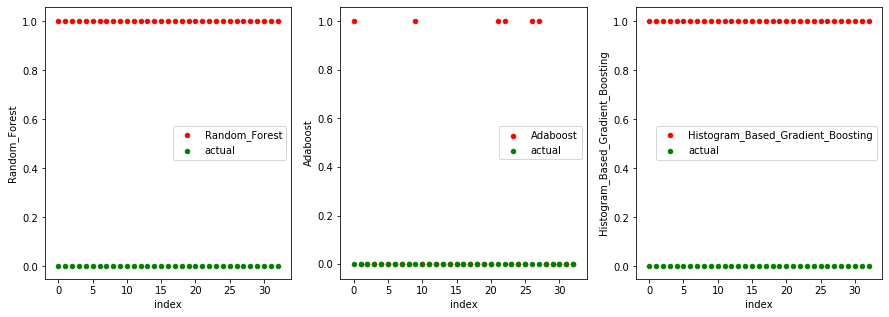

```python
plt.figure(figsize=(15,5))

ax = plt.subplot(1, 3, 1)
ax1 = misclassified_data.plot(kind='scatter', x='index', y='Random_Forest', color='r', ax=ax , label = 'Random_Forest')
ax2 = misclassified_data.plot(kind='scatter', x='index', y='actual', color='g', ax= ax1, label = 'actual')
ax.set_ylabel("Random_Forest")

ax = plt.subplot(1, 3, 2)
ax3 = misclassified_data.plot(kind='scatter', x='index', y='Adaboost', color='r', ax=ax,label = 'Adaboost')
ax4 = misclassified_data.plot(kind='scatter', x='index', y='actual', color='g', ax= ax3,label = 'actual')
ax.set_ylabel("Adaboost")

ax = plt.subplot(1, 3, 3)
ax5 = misclassified_data.plot(kind='scatter', x='index', y='Histogram_Based_Gradient_Boosting', color='r', ax=ax,label = 'Histogram_Based_Gradient_Boosting')
ax6 = misclassified_data.plot(kind='scatter', x='index', y='actual', color='g', ax= ax5,label = 'actual')
ax.set_ylabel('Histogram_Based_Gradient_Boosting')
plt.savefig('Missclassified.png')
```

# References

https://geopy.readthedocs.io/en/stable/  
https://nbviewer.jupyter.org/github/python-visualization/folium/blob/master/examples/MarkerCluster.ipynb  
https://python-visualization.github.io/folium/quickstart.html  
https://jupyter-gmaps.readthedocs.io/en/latest/tutorial.html  
https://altair-viz.github.io/  
https://sandcastle.cesium.com/  
https://elitedatascience.com/imbalanced-classes  
https://towardsdatascience.com/how-to-visualize-a-decision-tree-in-5-steps-19781b28ffe2  
https://medium.com/@dtuk81/confusion-matrix-visualization-fc31e3f30fea  
https://github.com/justmarkham/scikit-learn-videos/blob/master/09_classification_metrics.ipynb  
https://github.com/justmarkham/scikit-learn-videos/blob/master/08_grid_search.ipynb  
https://stackoverflow.com/questions/43061768/plotting-multiple-scatter-plots-pandas

## Library Used

**pandas:** https://pandas.pydata.org/docs/  
**re:**https://docs.python.org/3/library/re.html  
**train_test_split:**https://scikit-learn.org/stable/modules/generated/sklearn.model_selection.train_test_split.html  
**classification_report:**https://scikit-learn.org/stable/modules/generated/sklearn.metrics.classification_report.html  
**confusion_matrix:**https://scikit-learn.org/stable/modules/generated/sklearn.metrics.confusion_matrix.html  
**accuracy_score:**https://scikit-learn.org/stable/modules/generated/sklearn.metrics.accuracy_score.html  
**resample:**https://scikit-learn.org/stable/modules/generated/sklearn.utils.resample.html  
**shuffle:**https://scikit-learn.org/stable/modules/generated/sklearn.utils.shuffle.html  
**numpy:**https://numpy.org/doc/  
**seaborn:**https://seaborn.pydata.org/  
**matplotlib:**https://matplotlib.org/3.2.1/contents.html  
**metrics:**https://scikit-learn.org/stable/modules/model_evaluation.html  
**cross_val_score:**https://scikit-learn.org/stable/modules/generated/sklearn.model_selection.cross_val_score.html  
**Tree:**https://scikit-learn.org/stable/modules/generated/sklearn.tree.DecisionTreeClassifier.html  
**RandomizedSearchCV:**https://scikit-learn.org/stable/modules/generated/sklearn.model_selection.RandomizedSearchCV.html  
**GridSearchCV:**https://scikit-learn.org/stable/modules/generated/sklearn.model_selection.GridSearchCV.html  
**plot_tree:** https://scikit-learn.org/stable/modules/generated/sklearn.tree.plot_tree.html  
**enable_hist_gradient_boosting:**https://scikit-learn.org/stable/modules/generated/sklearn.ensemble.HistGradientBoostingRegressor.html  
**RBF:**https://scikit-learn.org/stable/modules/generated/sklearn.gaussian_process.kernels.RBF.html  
**LogisticRegression:**https://scikit-learn.org/stable/modules/linear_model.html#logistic-regression  
**Support Vector Classification (SVC):** https://scikit-learn.org/stable/modules/svm.html#classification  
**K-nearest neighbor(KNeighborsClassifiers):** https://scikit-learn.org/stable/modules/generated/sklearn.neighbors.KNeighborsClassifier.html  
**Decision Tree:** https://scikit-learn.org/stable/modules/tree.html#classification  
**Random Forest(RandomForestClassifier):** https://scikit-learn.org/stable/modules/ensemble.html#forests-of-randomized-trees  
**Stochastic Gradient Descent(SGDClassifier):** https://scikit-learn.org/stable/modules/sgd.html#classification  
**Gaussian Processes classification(GaussianProcessClassifier):** https://scikit-learn.org/stable/modules/gaussian_process.html#gaussian-process-classification-gpc  
**Naive Bayes(GaussianNB):**https://scikit-learn.org/stable/modules/naive_bayes.html#categorical-naive-bayes  
**Adaboost(AdaBoostClassifier):**https://scikit-learn.org/stable/modules/ensemble.html#adaboost  
**Gradient Boosting(GradientBoostingClassifier):**https://scikit-learn.org/stable/modules/ensemble.html#gradient-tree-boosting  
**Histogram-Based Gradient Boosting(HistGradientBoostingClassifier):**https://scikit-learn.org/stable/modules/ensemble.html#histogram-based-gradient-boosting  
**Neural network models(MLPClassifier):**https://scikit-learn.org/stable/modules/neural_networks_supervised.html#classification

**Tools used:**  
Jupyter Notebook, Visual Studio Code  
**Programing languages used:**  
Python, HTML, JavaScript